# SDS/CSC 293 Mini-Project 3: Multiple Regression

Group 24: Starry Zhou & Elaine Ye

Wednesday, March 27<sup>th</sup>, 2019

You will be submiting an entry to Kaggle’s [DonorsChoose.org Application Screening: Predict whether teachers’ project proposals are accepted](https://www.kaggle.com/c/donorschoose-application-screening/) by fitting a **logistic regression** model $\hat{f}(x)$.

# EDA

Read in data provided by Kaggle for this competition. They are organized in the `data/` folder of this RStudio project:

```r
training <- read_csv("data/train.csv")
test <- read_csv("data/test.csv")
sample_submission <- read_csv("data/sample_submission.csv")
```

Before performing any model fitting, you should always conduct an exploratory data analysis. This will help guide and inform your model fitting.

## Look at your data!

Always, ALWAYS, **ALWAYS** start by looking at your raw data. This gives you visual sense of what information you have to help build your predictive models. To get a full description of each variable, read the data dictionary in the `data_description.txt` file in the `data/` folder.

Note that the following code chunk has `eval = FALSE` meaning “don’t evaluate this chunk with knitting” because `.Rmd` files won’t knit if they include a `View()`:

```r
View(training)
glimpse(training)

View(test)
glimpse(test)
```

## Visualization

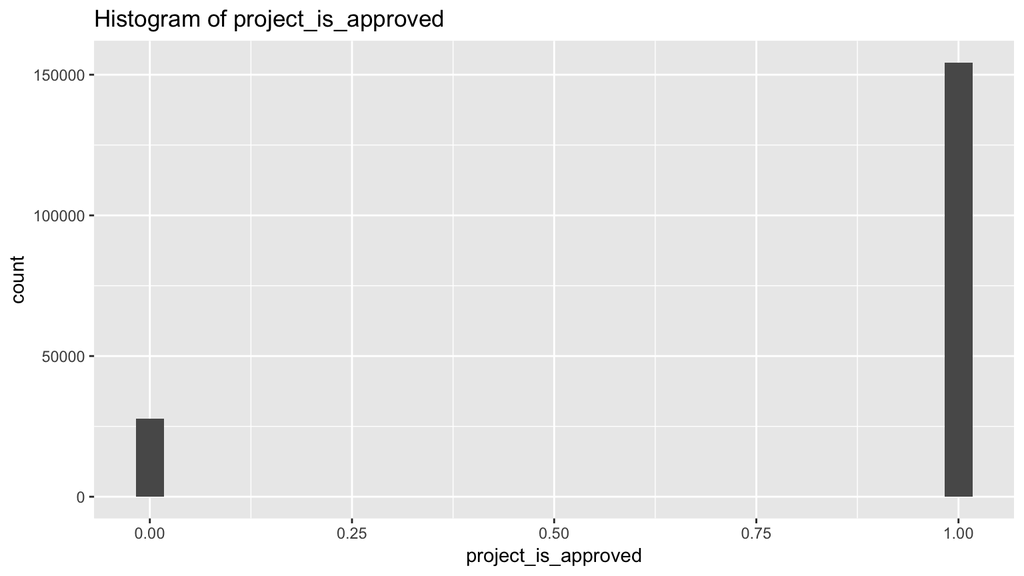

```r
training %>%
  ggplot(aes(training$project_is_approved)) +
  geom_histogram() +
  labs(x = "project_is_approved", title = "Histogram of project_is_approved")
```

# Minimally viable product

## Fit model on training

Fit a logistic regression model $\widehat{f}_1$ with only an intercept term on all the training data. In other words, your model will not use any predictor variables. Save this in `model_1`. What is the uniquely fitted probability?

```r
intercept <- mean(training$project_is_approved)

training$project_is_approved <- factor(training$project_is_approved, ordered = TRUE)

training <- training %>%
  mutate(pred1 = intercept)
```

$\widehat{ProjectIsApproved}$ = $.848$

## Estimate of your Kaggle score

Use the `yardstick` package to get an estimate of your Kaggle score: the area under the ROC curve (AUC). Crossvalidation is not necessary as with no predictor variables, we are in very little danger of overfitting the model.

```r
training %>%
  roc_auc(project_is_approved, pred1)
```

| .metric | .estimator | .estimate |
| --- | --- | --- |
| roc_auc | binary | 0.5 |

## Make predictions on test

Apply your `model_1` fitted model to the test data. What is the uniquely predicted probability?

```r
test <- test %>%
  mutate(pred1 = intercept)
intercept
```

```
## [1] 0.8476823
```

The uniquely predicted probability is $.848$.

## Create your submission CSV

```r
submission_mvp <- sample_submission %>%
  mutate(project_is_approved = intercept) %>%
  write_csv(path = "submission_mvp.csv")
```

## Screenshot of your Kaggle score

Our score based on our submission’s “Area under the Receiver Operating Characteristic Curve” was 0.5.

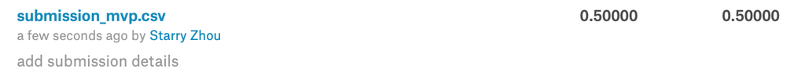

# Due diligence

## Plot ROC curve

Use the `yardstick` package to plot the ROC curve:

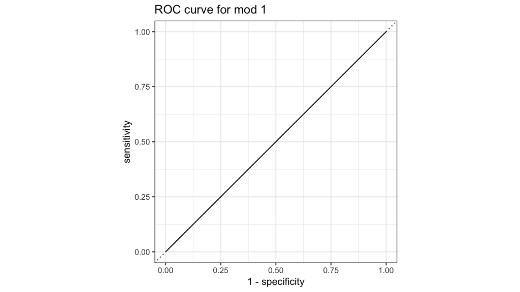

```r
roc_curve(data = training, truth = project_is_approved, pred1) %>% autoplot() +
  labs(title = "ROC curve for mod 1")
```

# Reaching for the stars

## Fit model on training

Fit a logistic regression model $\widehat{f}_2$ using a single numerical predictor variable $x$ on all the training data. Save this in `model_2`.

```r
mod2 <- glm(formula = project_is_approved ~ teacher_number_of_previously_posted_projects,
            family = binomial,
            data = training)

training <- training %>%
  mutate(pred2 = predict(mod2, training, type = "response"))
```

## Visualization

```r
training$project_is_approved <- ordered(training$project_is_approved, levels = c(1, 0))
```

Then display a single visualization that shows:

- The relationship between outcome variable $y$ and your numerical predictor variable $x$ with black points
- The relationship between the fitted probabilities $\widehat{p}$ from model $\widehat{f}_2$ and your numerical predictor variable $x$ with a red curve
- The fitted probabilities $\widehat{p}$ from model $\widehat{f}_1$ with a horizontal blue line at the same time.

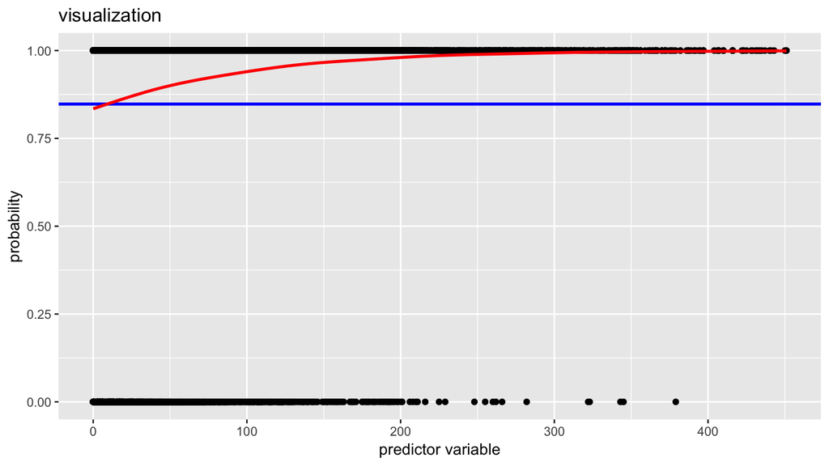

```r
ggplot(training, aes(x=teacher_number_of_previously_posted_projects, y=as.numeric(levels(training$project_is_approved))[training$project_is_approved])) +
 geom_point()+
 labs(x = "predictor variable", y = "probability", title = "visualization") +
 geom_hline(yintercept = intercept, col = "blue", size = 1) +
  geom_smooth(aes(x = teacher_number_of_previously_posted_projects, y = pred2), col = "red")
```

## Estimate of your Kaggle score

Use the `yardstick` package to get an estimate of your Kaggle score: the area under the ROC curve (AUC). Crossvalidation is not necessary as with only 1 predictor variable and so many points, we are in very little danger of overfitting the model.

```r
training %>%
  roc_auc(project_is_approved, pred2)
```

| .metric | .estimator | .estimate |
| --- | --- | --- |
| roc_auc | binary | 0.5607127 |

$\widehat{KaggleScore} = .5607$

## Make predictions on test

```r
test <- test %>%
  mutate(pred2 = predict(mod2, test, type = "response"))
```

## Create your submission CSV

```r
submission_rfs <- sample_submission %>%
  mutate(project_is_approved = test$pred2) %>%
  write_csv("submission_rfs.csv")
```

## Screenshot of your Kaggle score

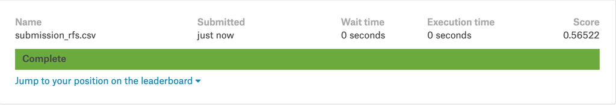

Our estimated score based on our submission’s “Area under the Receiver Operating Characteristic Curve” was $.5607$. The actual score is $.5652$. The estimation is quite close to the actual score.

$\widehat{KaggleScore} = .5607$

$KaggleScore = .5652$

## Plot ROC curve

```r
training %>%
  roc_auc(project_is_approved, pred2)
```

| .metric | .estimator | .estimate |
| --- | --- | --- |
| roc_auc | binary | 0.5607127 |

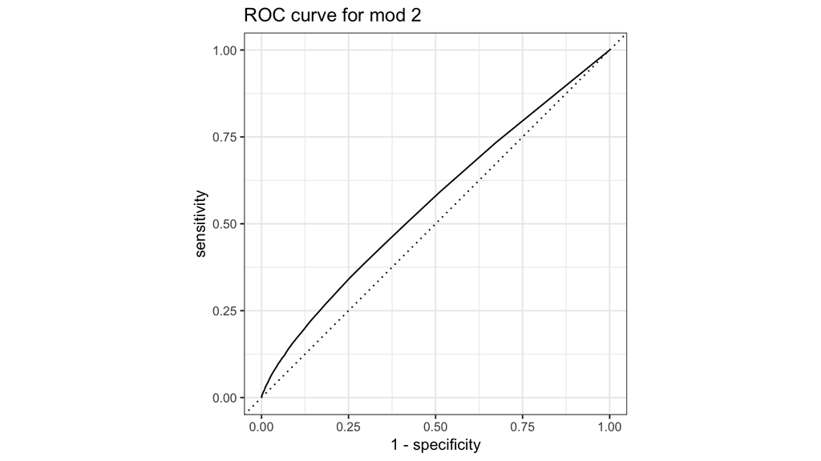

```r
training <- training %>%
  mutate(pred2 = predict(mod2, training, type = "response"))

roc_curve(data = training, truth = project_is_approved, pred2) %>% autoplot() +
  labs(title = "ROC curve for mod 2")
```

# Point of diminishing returns

## Fit model on training

Fit a logistic regression model $\widehat{f}_3$ using a single categorical predictor variable $x$ on all the training data. Save this in `model_3`.

```r
training$project_is_approved <- ordered(training$project_is_approved, levels = c(0, 1))

mod3 <- glm(formula = project_is_approved ~ project_grade_category,
           family = binomial,
           data = training)
```

## Estimate of your Kaggle score

Use the `yardstick` package to get an estimate of your Kaggle score: the area under the ROC curve (AUC). Crossvalidation is not necessary as with only 1 predictor variable and so many points, we are in very little danger of overfitting the model.

```r
training <- training %>%
  mutate(pred3 = predict(mod3, training, type = "response"))
```

```r
training$project_is_approved <- ordered(training$project_is_approved, levels = c(1, 0))

training %>%
  roc_auc(project_is_approved, pred3)
```

| .metric | .estimator | .estimate |
| --- | --- | --- |
| roc_auc | binary | 0.5115242 |

$\widehat{KaggleScore} = .5115$

## Visualization

Then display a single visualization that shows:

- The relationship between the fitted probabilities $\widehat{p}$ from model $\widehat{f}_3$ and your categorical predictor variable $x$
- The fitted probabilities $\widehat{p}$ from model $\widehat{f}_1$ with a horizontal blue line at the same time.

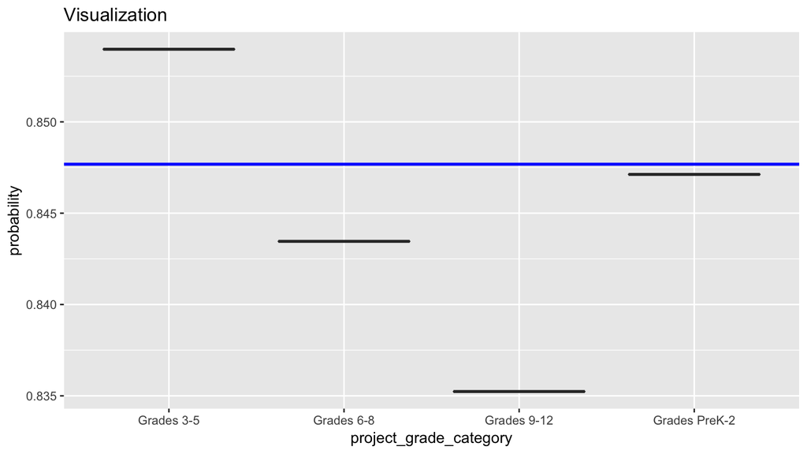

```r
training %>%
  ggplot(aes(x = project_grade_category, y = pred3)) +
  geom_boxplot() +
  geom_hline(yintercept = intercept, col = "blue", size = 1) +
  labs(y = "probability", title = "Visualization")
```

## Make predictions on test

```r
test <- test %>%
  mutate(pred3 = predict(mod3, test, type = "response"))
```

## Create your submission CSV

```r
submission_drt <- sample_submission %>%
  mutate(project_is_approved = test$pred3) %>%
  write_csv("submission_drt.csv")
```

## Screenshot of your Kaggle score

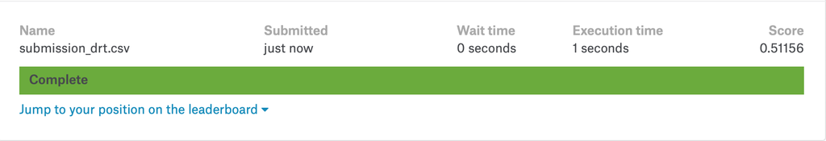

Our estimated score based on our submission’s “Area under the Receiver Operating Characteristic Curve” was $.5115$. The actual score is $.5116$. The estimation is quite close to the actual score.

$\widehat{KaggleScore} = .5115$

$KaggleScore = .5116$

## Plot ROC curve

Use the `yardstick` package to plot the ROC curve:

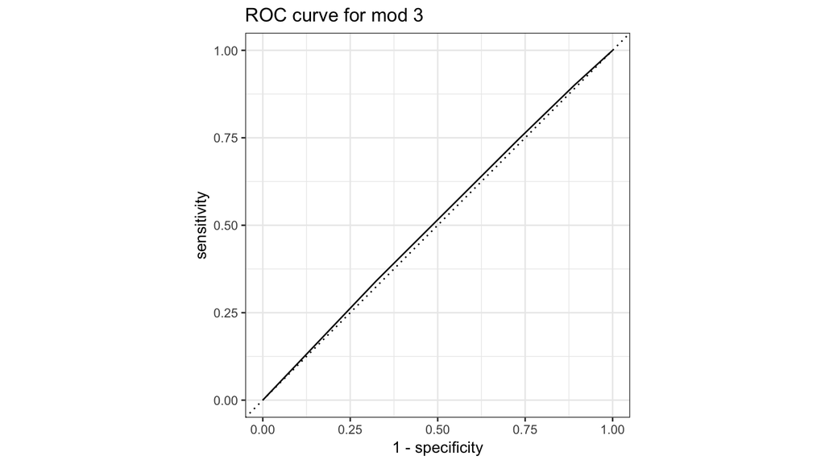

```r
training <- training %>%
  mutate(pred3 = predict(mod3, training, type = "response"))

roc_curve(data = training, truth = project_is_approved, pred3) %>% autoplot() +
  labs(title = "ROC curve for mod 3")
```